# Featuring Engineering Practice

Machine Learning II

# Introduction

In this first practical session we will make the first contact with the featuring engineering process and its impact in a ML pipeline. Feature engineering is a very important part of the process of developing prediction models. It is considered, by many authors, an art, and it involves human-driven design and intuition. Feature engineering sessions will try to uncover the most relevant issues that must be addressed, and also provide some guidelines to start building sound feature engineering processes for ML problems.

The experimental dataset we are going to use is the House Prices Dataset. It includes 79 explanatory variables of residential homes. For more details on the dataset and the competition see https://www.kaggle.com/c/house-prices-advanced-regression-techniques.

## What is my goal?

- I have to predict predict the final price of each home (Therefore, this is a regression task)
- I have to use the feature engineering techniques explained in class to transform the dataset.

# Data Reading and preparation

The dataset is offered in two separated fields, one for the training and another one for the test set. Best way of moving forward is to sign in into Kaggle and download them from the ‘Data’ section.

```r
training_data = read.csv(file = file.path("data", "train.csv"))
test_data = read.csv(file = file.path("data", "test.csv"))
```

```r
length(unique(training_data$Id)) == nrow(training_data)
```

```
## [1] TRUE
```

There is no duplicates so we remove the Id column

```r
training_data = training_data[ , -which(names(training_data) %in% c("Id"))]
```

## Hunting NAs

Our dataset is filled with many missing values, therefore, before we can build any predictive model we’ll clean our data by filling in all NA’s with appropriate values.

Counting columns with null values

```r
na.cols <- which(colSums(is.na(training_data)) > 0)
sort(colSums(sapply(training_data[na.cols], is.na)), decreasing = TRUE)
```

```
##       PoolQC  MiscFeature        Alley        Fence  FireplaceQu
##         1453         1406         1369         1179          690
##  LotFrontage   GarageType  GarageYrBlt GarageFinish   GarageQual
##          259           81           81           81           81
##   GarageCond BsmtExposure BsmtFinType2     BsmtQual     BsmtCond
##           81           38           38           37           37
## BsmtFinType1   MasVnrType   MasVnrArea   Electrical
##           37            8            8            1
```

```r
paste('There are', length(na.cols), 'columns with missing values')
```

```
## [1] "There are 19 columns with missing values"
```

NA imputation:

```r
# Alley : NA means "no alley access"
training_data$Alley = factor(training_data$Alley, levels=c(levels(training_data$Alley), "None"))
training_data$Alley[is.na(training_data$Alley)] = "None"

training_data$BedroomAbvGr[is.na(training_data$BedroomAbvGr)] <- 0

# Bsmt : NA for basement features is "no basement"
training_data$BsmtQual = factor(training_data$BsmtQual, levels=c(levels(training_data$BsmtQual), "No"))
training_data$BsmtQual[is.na(training_data$BsmtQual)] = "No"

training_data$BsmtCond = factor(training_data$BsmtCond, levels=c(levels(training_data$BsmtCond), "No"))
training_data$BsmtCond[is.na(training_data$BsmtCond)] = "No"

training_data$BsmtExposure[is.na(training_data$BsmtExposure)] = "No"

training_data$BsmtFinType1 = factor(training_data$BsmtFinType1, levels=c(levels(training_data$BsmtFinType1), "No"))
training_data$BsmtFinType1[is.na(training_data$BsmtFinType1)] = "No"

training_data$BsmtFinType2 = factor(training_data$BsmtFinType2, levels=c(levels(training_data$BsmtFinType2), "No"))
training_data$BsmtFinType2[is.na(training_data$BsmtFinType2)] = "No"

# Fence : NA means "no fence"
training_data$Fence = factor(training_data$Fence, levels=c(levels(training_data$Fence), "No"))
training_data$Fence[is.na(training_data$Fence)] = "No"

# FireplaceQu : NA means "no fireplace"
training_data$FireplaceQu = factor(training_data$FireplaceQu, levels=c(levels(training_data$FireplaceQu), "No"))
training_data$FireplaceQu[is.na(training_data$FireplaceQu)] = "No"

# Garage : NA for garage features is "no garage"
training_data$GarageType = factor(training_data$GarageType, levels=c(levels(training_data$GarageType), "No"))
training_data$GarageType[is.na(training_data$GarageType)] = "No"

training_data$GarageFinish = factor(training_data$GarageFinish, levels=c(levels(training_data$GarageFinish), "No"))
training_data$GarageFinish[is.na(training_data$GarageFinish)] = "No"

training_data$GarageQual = factor(training_data$GarageQual, levels=c(levels(training_data$GarageQual), "No"))
training_data$GarageQual[is.na(training_data$GarageQual)] = "No"

training_data$GarageCond = factor(training_data$GarageCond, levels=c(levels(training_data$GarageCond), "No"))
training_data$GarageCond[is.na(training_data$GarageCond)] = "No"

# LotFrontage : NA most likely means no lot frontage
training_data$LotFrontage[is.na(training_data$LotFrontage)] <- 0

# MasVnrType : NA most likely means no veneer
training_data$MasVnrType[is.na(training_data$MasVnrType)] = "None"
training_data$MasVnrArea[is.na(training_data$MasVnrArea)] <- 0

# MiscFeature : NA = "no misc feature"
training_data$MiscFeature = factor(training_data$MiscFeature, levels=c(levels(training_data$MiscFeature), "No"))
training_data$MiscFeature[is.na(training_data$MiscFeature)] = "No"

# PoolQC : data description says NA means "no pool"
training_data$PoolQC = factor(training_data$PoolQC, levels=c(levels(training_data$PoolQC), "No"))
training_data$PoolQC[is.na(training_data$PoolQC)] = "No"

# Electrical : NA means "UNK"
training_data$Electrical = factor(training_data$Electrical, levels=c(levels(training_data$Electrical), "UNK"))
training_data$Electrical[is.na(training_data$Electrical)] = "UNK"

# GarageYrBlt: It seems reasonable that most houses would build a garage when the house itself was built.
idx <- which(is.na(training_data$GarageYrBlt))
training_data[idx, 'GarageYrBlt'] <- training_data[idx, 'YearBuilt']

na.cols <- which(colSums(is.na(training_data)) > 0)
paste('There are now', length(na.cols), 'columns with missing values')
```

```
## [1] "There are now 0 columns with missing values"
```

We repeat the process for test_data

```r
# Alley : data description says NA means "no alley access"
test_data$Alley = factor(test_data$Alley, levels=c(levels(test_data$Alley), "None"))
test_data$Alley[is.na(test_data$Alley)] = "None"

test_data$BedroomAbvGr[is.na(test_data$BedroomAbvGr)] <- 0

# BsmtQual etc : data description says NA for basement features is "no basement"
test_data$BsmtQual = factor(test_data$BsmtQual, levels=c(levels(test_data$BsmtQual), "No"))
test_data$BsmtQual[is.na(test_data$BsmtQual)] = "No"

test_data$BsmtCond = factor(test_data$BsmtCond, levels=c(levels(test_data$BsmtCond), "No"))
test_data$BsmtCond[is.na(test_data$BsmtCond)] = "No"

test_data$BsmtExposure[is.na(test_data$BsmtExposure)] = "No"

test_data$BsmtFinType1 = factor(test_data$BsmtFinType1, levels=c(levels(test_data$BsmtFinType1), "No"))
test_data$BsmtFinType1[is.na(test_data$BsmtFinType1)] = "No"

test_data$BsmtFinType2 = factor(test_data$BsmtFinType2, levels=c(levels(test_data$BsmtFinType2), "No"))
test_data$BsmtFinType2[is.na(test_data$BsmtFinType2)] = "No"

# Fence : data description says NA means "no fence"
test_data$Fence = factor(test_data$Fence, levels=c(levels(test_data$Fence), "No"))
test_data$Fence[is.na(test_data$Fence)] = "No"

# FireplaceQu : data description says NA means "no fireplace"
test_data$FireplaceQu = factor(test_data$FireplaceQu, levels=c(levels(test_data$FireplaceQu), "No"))
test_data$FireplaceQu[is.na(test_data$FireplaceQu)] = "No"

# GarageType etc : data description says NA for garage features is "no garage"
test_data$GarageType = factor(test_data$GarageType, levels=c(levels(test_data$GarageType), "No"))
test_data$GarageType[is.na(test_data$GarageType)] = "No"

test_data$GarageFinish = factor(test_data$GarageFinish, levels=c(levels(test_data$GarageFinish), "No"))
test_data$GarageFinish[is.na(test_data$GarageFinish)] = "No"

test_data$GarageQual = factor(test_data$GarageQual, levels=c(levels(test_data$GarageQual), "No"))
test_data$GarageQual[is.na(test_data$GarageQual)] = "No"

test_data$GarageCond = factor(test_data$GarageCond, levels=c(levels(test_data$GarageCond), "No"))
test_data$GarageCond[is.na(test_data$GarageCond)] = "No"

# LotFrontage : NA most likely means no lot frontage
test_data$LotFrontage[is.na(test_data$LotFrontage)] <- 0

# MasVnrType : NA most likely means no veneer
test_data$MasVnrType[is.na(test_data$MasVnrType)] = "None"
test_data$MasVnrArea[is.na(test_data$MasVnrArea)] <- 0

# MiscFeature : data description says NA means "no misc feature"
test_data$MiscFeature = factor(test_data$MiscFeature, levels=c(levels(test_data$MiscFeature), "No"))
test_data$MiscFeature[is.na(test_data$MiscFeature)] = "No"

# PoolQC : data description says NA means "no pool"
test_data$PoolQC = factor(test_data$PoolQC, levels=c(levels(test_data$PoolQC), "No"))
test_data$PoolQC[is.na(test_data$PoolQC)] = "No"
```

## Factorize features

Some numerical features are actually really categories. Therefore we transform the feature from numeric to categorical

```r
training_data$MSSubClass <- as.factor(training_data$MSSubClass)
training_data$MoSold <- as.factor(training_data$MoSold)

test_data$MSSubClass <- as.factor(test_data$MSSubClass)
test_data$MoSold <- as.factor(test_data$MoSold)
```

## Skewness

If we print the histogram of the target value, we obseve a large skewness in the Target value (i.e., the distribution in not normally distributed). To solve that we log transform this variable so that it becomes normally distributed. A normally distributed target variable helps in the modeling step (i.e., the finding of the relationship between target and independent variables).

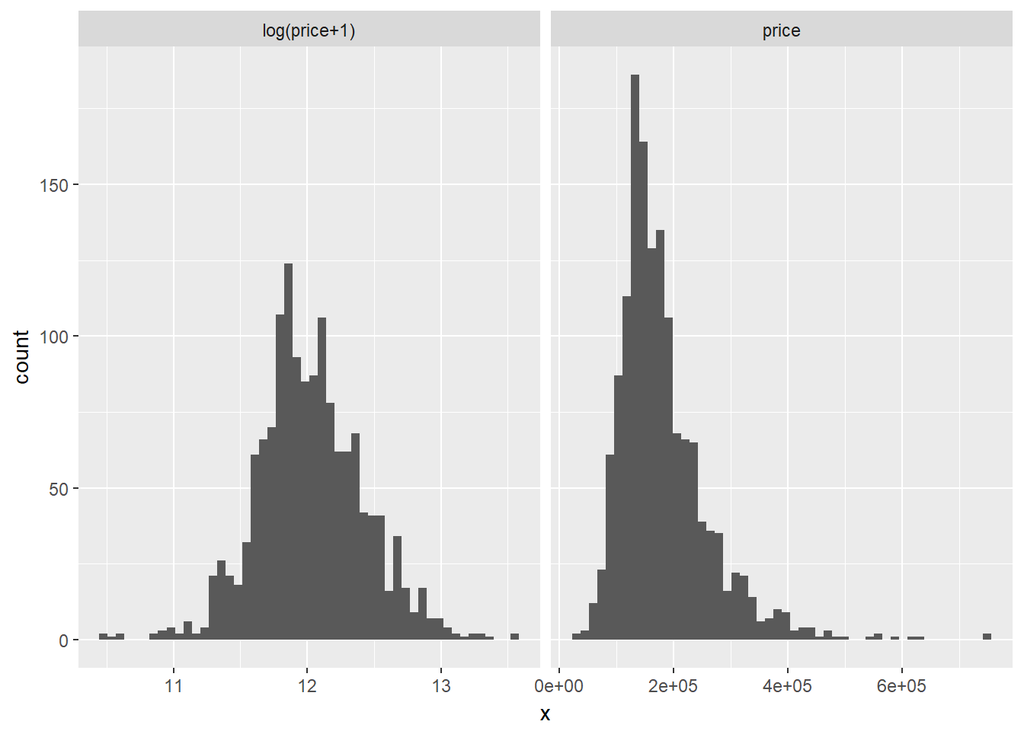

```r
# get data frame of SalePrice and log(SalePrice + 1) for plotting
df <- rbind(data.frame(version="log(price+1)",x=log(training_data$SalePrice + 1)),
            data.frame(version="price",x=training_data$SalePrice))

ggplot(data=df) +
  facet_wrap(~version,ncol=2,scales="free_x") +
  geom_histogram(aes(x=x), bins = 50)
```

We therefore transform the target value applying log.

```r
# Log transform the target for official scoring
training_data$SalePrice <- log1p(training_data$SalePrice)
```

The same “skewness” observed in the target variable also affects other variables. To facilitate the application of the regression model we are going to also eliminate this skewness For numeric feature with excessive skewness, perform log transformation.

```r
column_types <- sapply(names(training_data),function(x){class(training_data[[x]])})
numeric_columns <-names(column_types[column_types != "factor"])

# skew of each variable
skew <- sapply(numeric_columns,function(x){skewness(training_data[[x]],na.rm = T)})

# transform all variables above a threshold skewness.
skew <- skew[skew > 0.75]
for(x in names(skew)) {
  training_data[[x]] <- log(training_data[[x]] + 1)
}
```

The same for the test data

```r
column_types <- sapply(names(test_data),function(x){class(test_data[[x]])})
numeric_columns <-names(column_types[column_types != "factor"])

skew <- sapply(numeric_columns,function(x){skewness(test_data[[x]],na.rm = T)})
skew <- skew[skew > 0.75]
for(x in names(skew)) {
  test_data[[x]] <- log(test_data[[x]] + 1)
}
```

## Train, Validation Spliting

We are going to split the annotated dataset in training and validation for the later evaluation of our regression models

```r
# I found this function, that is worth to save for future ocasions.
splitdf <- function(dataframe, seed=NULL) {
  if (!is.null(seed)) set.seed(seed)
    index <- 1:nrow(dataframe)
    trainindex <- sample(index, trunc(length(index)/1.5))
    trainset <- dataframe[trainindex, ]
    testset <- dataframe[-trainindex, ]
    list(trainset=trainset,testset=testset)
}
splits <- splitdf(training_data, seed=1)
training <- splits$trainset
validation <- splits$testset
```

If we inspect in detail the categorical variables of the dataset, we’ll see that some are incomplete: they only have a unique value for all the dataset. These features are not valuable. Remember the three aspects that a feature should have: informative, **discriminative** and independent. Incomplete cases are not discriminative at all. In addition, this might create problems when fitting the regression model

The following code show the incomplete cases

```r
## remove incomplete cases
paste("Training set incomplete cases")
```

```
## [1] "Training set incomplete cases"
```

```r
sapply(lapply(na.omit(training)[sapply(na.omit(training), is.factor)], droplevels), nlevels)
```

```
##    MSSubClass      MSZoning        Street         Alley      LotShape
##            15             5             2             3             4
##   LandContour     Utilities     LotConfig     LandSlope  Neighborhood
##             4             2             5             3            25
##    Condition1    Condition2      BldgType    HouseStyle     RoofStyle
##             8             7             5             8             6
##      RoofMatl   Exterior1st   Exterior2nd    MasVnrType     ExterQual
##             7            14            16             4             4
##     ExterCond    Foundation      BsmtQual      BsmtCond  BsmtExposure
##             5             6             5             5             4
##  BsmtFinType1  BsmtFinType2       Heating     HeatingQC    CentralAir
##             7             7             5             5             2
##    Electrical   KitchenQual    Functional   FireplaceQu    GarageType
##             6             4             6             6             7
##  GarageFinish    GarageQual    GarageCond    PavedDrive        PoolQC
##             4             6             6             3             4
##         Fence   MiscFeature        MoSold      SaleType SaleCondition
##             5             4            12             9             6
```

```r
paste("Validation set incomplete cases")
```

```
## [1] "Validation set incomplete cases"
```

```r
sapply(lapply(na.omit(validation)[sapply(na.omit(validation), is.factor)], droplevels), nlevels)
```

```
##    MSSubClass      MSZoning        Street         Alley      LotShape
##            15             5             2             3             4
##   LandContour     Utilities     LotConfig     LandSlope  Neighborhood
##             4             1             5             3            25
##    Condition1    Condition2      BldgType    HouseStyle     RoofStyle
##             9             5             5             8             5
##      RoofMatl   Exterior1st   Exterior2nd    MasVnrType     ExterQual
##             5            12            13             4             4
##     ExterCond    Foundation      BsmtQual      BsmtCond  BsmtExposure
##             4             6             5             4             4
##  BsmtFinType1  BsmtFinType2       Heating     HeatingQC    CentralAir
##             7             7             4             4             2
##    Electrical   KitchenQual    Functional   FireplaceQu    GarageType
##             4             4             7             6             7
##  GarageFinish    GarageQual    GarageCond    PavedDrive        PoolQC
##             4             6             5             3             3
##         Fence   MiscFeature        MoSold      SaleType SaleCondition
##             5             3            12             8             5
```

```r
paste("Test set incomplete cases")
```

```
## [1] "Test set incomplete cases"
```

```r
sapply(lapply(na.omit(test_data)[sapply(na.omit(test_data), is.factor)], droplevels), nlevels)
```

```
##    MSSubClass      MSZoning        Street         Alley      LotShape
##            16             5             2             3             4
##   LandContour     Utilities     LotConfig     LandSlope  Neighborhood
##             4             1             5             3            25
##    Condition1    Condition2      BldgType    HouseStyle     RoofStyle
##             9             5             5             7             6
##      RoofMatl   Exterior1st   Exterior2nd    MasVnrType     ExterQual
##             4            11            13             4             4
##     ExterCond    Foundation      BsmtQual      BsmtCond  BsmtExposure
##             5             6             5             5             4
##  BsmtFinType1  BsmtFinType2       Heating     HeatingQC    CentralAir
##             7             7             3             5             2
##    Electrical   KitchenQual    Functional   FireplaceQu    GarageType
##             4             4             6             6             6
##  GarageFinish    GarageQual    GarageCond    PavedDrive        PoolQC
##             3             4             5             3             3
##         Fence   MiscFeature        MoSold      SaleType SaleCondition
##             5             4            12             9             6
```

We remove the detected incomplete cases

```r
# Remove the Utilities feature from the dataset (It only has one value)
training <- training[,-which(names(training) == "Utilities")]
validation <- validation[,-which(names(validation) == "Utilities")]
test_data <- test_data[,-which(names(test_data) == "Utilities")]
```